[figure not shown]

# Bones of the Game:

## Possession as the Fundamental Unit of Rugby 7s Performance Analysis

Many believe that **possession** is the decisive factor in winning rugby sevens matches. [[1]](http://www.ncbi.nlm.nih.gov/pmc/articles/PMC3990890/) [[2]](http://www.rugbytoday.com/7s/essentials-sevens-coaching-tips) Finding statistics that connect possession to winning is surprisingly difficult. Possession statistics borrowed from 15s do not transfer well to sevens. An earlier study reported that pass completions and rucks indicate an *inability* to score in rugby sevens. [[3]](http://www.rugby7.com/cm_genat.asp?L=E) When evenly matched teams play, the odds that the team with more time of possession will win is only %53 – slightly better than chance. [[4]](https://starting7s.com/2016/12/11/analyzing-time-of-possession-in-7s/) Winning teams often complete less passes, retain fewer rucks, and hold the ball for less time than their opponents.

Recent series results support these studies. In the 2014-2015 HSBC Sevens Series, Japan and Brazil had passes per match and time of possession statistics at or above the series average. Both teams scored few points and rarely won. Scotland lead all core teams in pass completions, rucks won, and time of possession differential yet finished seventh overall. Fiji and South Africa held the ball and passed less than the series average en route to finishing first and second in the series overall. [[5]](https://github.com/jliberma/rugby7s/raw/master/doc/2014-2015_Sevens_report.pdf)

This post introduces the **individual possession** as a fundamental unit of performance statistic that connects possession with winning in rugby 7s. An individual possession is a discrete scoring opportunity. It begins when a team takes ownership of the ball and ends when the team in possession either scores, turns the ball over to their opponent, or time expires. Individual possession – and its corallaries **total possession count** and **possession differential** – not only connect winning with possession, but also provide a simple framework for analyzing rugby 7s performance.

The remainder of this post uses a unique data set drawn from the 2014-2015 HSBC Sevens Series to describe 7s matches using possession count and establish the relationship between possession count and winning. It includes the source code and data necessary to reproduce the analysis. The post concludes with directions for future exploration.

## Possession defined

For the purposes of this study each possession corresponds to a **discrete scoring opportunity**. A possession begins when a team holds the ball following a restart or turnover. It continues through phases including the time the ball is both in and out of play. A possession ends when the team in possession scores, turns the ball over to their opponent, or time expires.

For example, Team A wins a restart. They retain the ball through several phases. Eventually a tackler on Team B is penalized for not releasing the ball carrier. Team A elects to kick the penalty to touch. Team A wins the subsequent lineout and scores a try. By our definition all of this activity amounts to one possession. The stoppages due to penalties, set piece play, or infractions did not trigger a new possession because the ball did not change hands.

Continuing with this example, Team A reclaims the restart following their try. This begins their **second** possession. A player from Team B poaches the ball during a tackle, ending Team A’s second possession and beginning Team B’s first. Possession alternates in this manner until points are scored or time expires in the half.

## Possessions per match

This section of the analysis uses historical match data to describe the typical match in terms of ball possession. The data set is called **ws72014_possession_stats.csv**. The match data were collected through notational analysis of every rugby match in the 2014-2015 HSBC Sevens Series. Each row of the data set represents a unique possession.

```
##   SERIES.MATCH EVENT MATCH ROUND HALF POSS TEAM OPP    SOURCE START END
## 1            1  GC7s     1  Pool    1    1  ARG ENG        PK     5   5
## 2            1  GC7s     1  Pool    1    2  ENG ARG      Kick     2   3
## 3            1  GC7s     1  Pool    1    3  ARG ENG      Kick    12  12
## 4            1  GC7s     1  Pool    1    4  ENG ARG Intercept     4   5
## 5            1  GC7s     1  Pool    1    5  ARG ENG Intercept    11  14
##          LOST                                SOURCE.NOTE       LOST.NOTE
## 1        Kick PK: illegal ctc on restart by kicking team Kick: PG missed
## 2        Kick
## 3          HE                                               HE: knock on
## 4 Intercepted
## 5         TRY                                             TRY: converted
```

There are fourteen columns. The columns that pertain to this analysis include:

- SERIES.MATCH: series match number (1-405)
- HALF: 1 or 2
- POSS: cumulative per-match possession number including both teams
- TEAM: the team with possession
- OPP: their opponent

The analysis begins by counting the total number of possessions in each match. This is accomplished by counting the number of rows that contain each unique series match ID, 1-405.

```
##  1  2  3  4  5  6  7  8  9 10
## 20 16 15 18 20 22 20 12 18 17
```

Match 1 had 20 total possessions, match 2 had 16, and so on. Because the possession per match count is based on series match ID, and not team name, it represents the total number of possessions in each match including both teams.

Summarize possessions per match:

```
##    Min. 1st Qu.  Median    Mean 3rd Qu.    Max.
##    7.00   15.00   17.00   17.02   19.00   31.00
```

- The average possession count across all matches was 17.02 with a standard deviation of 3.27.
- The median average of 17 agrees with the mean, indicating that the mean is probably representative of a typical match and not overly skewed by outliers.
- 7 and 31 were the minimum and maximum total possession counts per match.
8. Visualize how possession counts were distributed across matches by plotting *poss.per.match* as a cumulative density function.

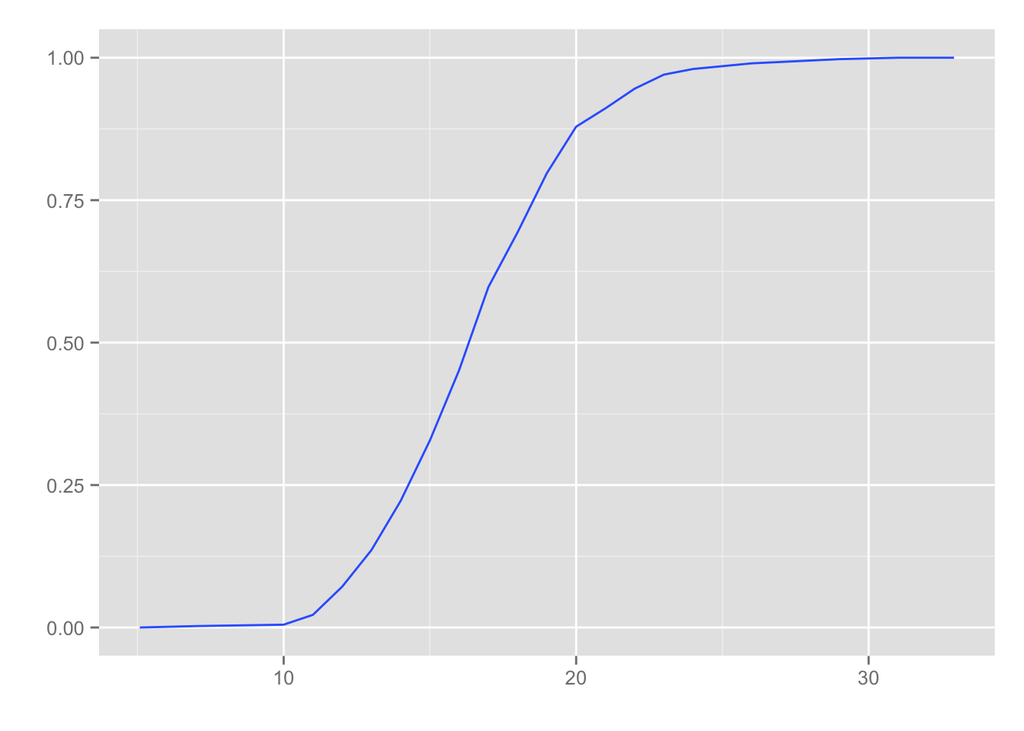

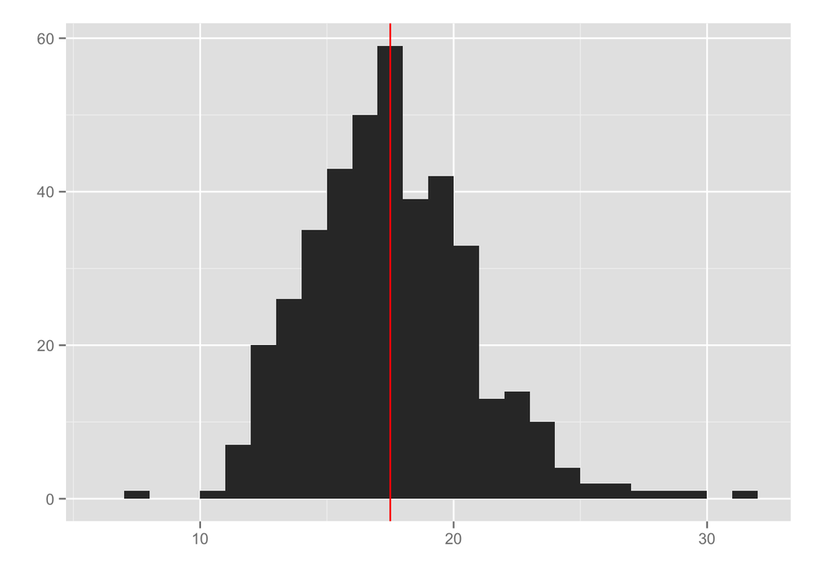

- At first glance the histogram appears to have a bell shaped distribution symmetrical around the mean.
- However, the histogram is slightly right-skewed. Matches that strayed from the mean tended to have more possessions rather than less.

The graph does not show what causes the skew. It could be caused by 20 minute finals or overtime matches. Possession also changes more frequently in wet conditions due to tactical kicking and handling errors. The small outliers should not affect the overall analysis greatly .

10. According to the exploratory data analysis, *the majority of World Sevens Series matches had between 14 and 20 possessions* , with an average of *17 total possessions between both teams*.

Assuming both teams get equal possession – an assumption we explore in the next section – then each team has only four scoring opportunities per half. When seen in this light, the critical importance of every rugby sevens possession becomes clear.

## Winning Possession Margin

The exploratory data analysis determined most of the 2014-2015 series matches had between 14 and 20 possessions. This section investigates how those possessions were divided between the winning and losing teams. This is called the **possession differential**. Does a favorable possession differential increase the likelihood of winning, and, if so, by how much?

This section introduces a statistic called the **winning possession margin** (wpm) to help answer these questions. Wpm shows how many possessions the match winner had relative to the loser. Wpm is similar to the possession differnential except that it explcitly measures the differential from the standpoint of the eventual match winner.

Calculate the wpm by subtracting the loser’s possession count from the winner’s. The result is positive when the winner had more possessions than the loser and negative when the winner had less possession than the loser. A wpm of zero means both teams had the same number of possessions in the match.

1. Start by scoring all matches using the match_score_poss() function provided by poss_func.R.

```r
all_scores <- match_score_poss(ws7s_poss)
```

2. Determine match winners and calculate the winning possession margin for each match by subtracting the loser’s possession count from the winner’s.

```r
wpm <- all_scores %>%
  filter(! points.1 == points.2) %>%
  mutate(wpm = ifelse(points.1 > points.2,
                      count.1-count.2,
                      count.2-count.1),
         pos = wpm >=0) %>%
  select(match, wpm, pos) %>%
  arrange(wpm)
```

Tie matches were removed from the analysis. There were 9 ties which left 396 matches for analysis from the original data set.

3. Find the average, maximum, and minimum of all matches wpm using summary().

```
##    Min. 1st Qu.  Median    Mean 3rd Qu.    Max.
## -3.0000  0.0000  1.0000  0.9924  2.0000  7.0000
```

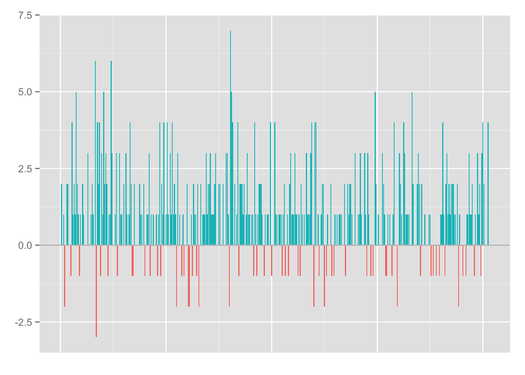

Each bar on the X axis of this graph corresponds to a series match. The height of each bar on the Y axis represents winning possession margin. Blue bars denote that that the winner had more possessions than the loser. Red bars deonte that the loser had more possessions than the winner.

## Does probability of winning increase as the possession margin increases?

Not surprisingly, teams with a possession advantage won more often than their opponent. However, it is interesting to note that a one possession advantage often separates winning from losing. This section investigates whether the probability of winning increases as the possession differential increases.

1. According to the previous section, possession differentials ranged from zero to seven. Calculate how many matches had absolute possession margins from one to seven. This calculation includes matches that ended in a tie.

```
## [1] "wpm == 0 : 104"
## [1] "wpm == 1 : 167"
## [1] "wpm == 2 : 72"
## [1] "wpm == 3 : 33"
## [1] "wpm == 4 : 21"
## [1] "wpm == 5 : 5"
## [1] "wpm == 6 : 2"
## [1] "wpm == 7 : 1"
```